# GRANITUS hypothesis testing

# I. INTRO

Hypotheses taken from the OSF preregistration document.

# II. ERP EXPERIMENT (GRAMMATICALITY JUDGMENTS)

## 1. HYPOTHESIS 1

Work in progress

## 2. HYPOTHESIS 2

Work in progress

## 3. HYPOTHESIS 3

Work in progress

# III. ERP EXPERIMENT (EEG SIGNAL)

## 1. HYPOTHESIS 4

Work in progress

## 2. HYPOTHESIS 5

Work in progress

## 3. HYPOTHESIS 6

Work in progress

## 4. HYPOTHESIS 7

Work in progress

## 5. HYPOTHESIS 8

Work in progress

# IV. PERCEPTUAL EXPERIMENT

All tests done with the “perc_data.csv” data set.

## 1. HYPOTHESIS 9

### Prediction

Phonetic errors (SENT_TYPE:PHON) will have more influence on the assessment of the speaker’s qualities (SPEAKER_PERSONAL_RATING) than grammatical errors (SENT_TYPE:GRAM). This effect will be reduced or absent in native-accented speech (ACCENT).

*[The original prediction from OSF did not involve the Personality Dimension (warmth/competence). I added it as a factor to the model because this was an important part of the experiment design (each sentence was always presented twice: with warmth adjectives and competence adjectives). I did not test its influence for now because it would require interpreting a triple interaction (Sentence Type x Accent x Personality Dimension). We can think about doing it later. -PG]*

### Variables

**Personality Rating (SPEAKER_PERSONAL_RATING)**

Outcome variable measured in the Perceptual Experiment. Created by averaging the ratings for 4 adjectives describing the speaker’s personality traits in terms of warmth or competence for each sentence. Scale: 1(negative)-7(positive). Every participant provided 12 ratings (6 warmth, 6 competence) in each of the 6 main experimental conditions (NAT-WF, NAT-GRAM, NAT-PHON, FOR-WF, FOR-GRAM, FOR-PHON), giving 72 datapoints per participant (36 warmth, 36 competence).

**Personality Dimension (PERSONAL_DIMENSION)**

Type of personality traits rated for a given sentence. Warmth traits (WARMTH), competence traits (COMP).

**Sentence Type (SENT_TYPE)**

Type of sentence. Correct (WF), with grammatical error (GRAM), with phonetic error (PHON).

**Accent (ACCENT)**

The accent of the speaker recording a given sentence. Native-accented (NATIVE), foreign-accented (FOREIGN).

### Descriptive statistics, plots

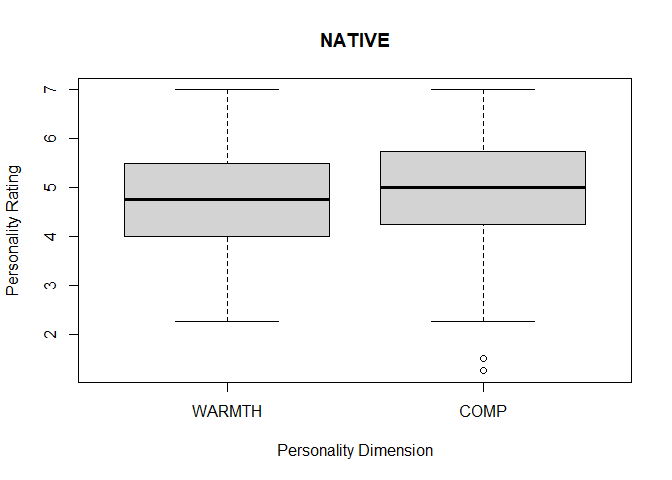

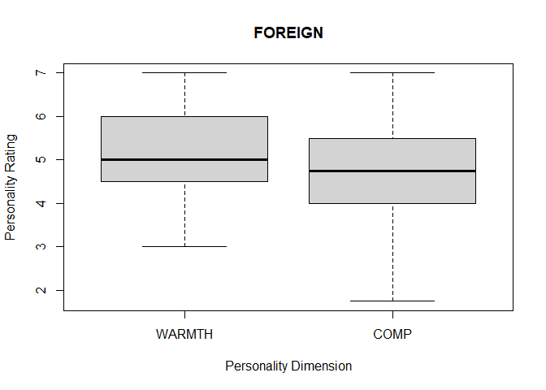

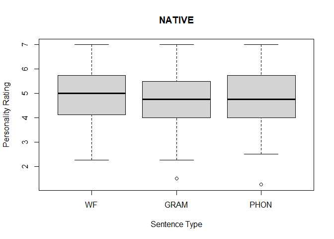

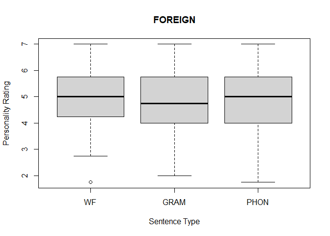

### Models

```
## Linear mixed model fit by REML. t-tests use Satterthwaite's method [
## lmerModLmerTest]
## Formula: SPEAKER_PERSONAL_RATING ~ SENT_TYPE + ACCENT + PERSONAL_DIMENSION +
##     SENT_TYPE:ACCENT + (1 | PART_ID) + (1 | PERC_SENT_ID)
##    Data: perc_data_var
##
## REML criterion at convergence: 4837.7
##
## Scaled residuals:
##     Min      1Q  Median      3Q     Max
## -4.5103 -0.4867  0.0518  0.5938  3.1203
##
## Random effects:
##  Groups       Name        Variance Std.Dev.
##  PERC_SENT_ID (Intercept) 0.01606  0.1267
##  PART_ID      (Intercept) 0.62699  0.7918
##  Residual                 0.49951  0.7068
## Number of obs: 2160, groups:  PERC_SENT_ID, 108; PART_ID, 30
##
## Fixed effects:
##                               Estimate Std. Error         df t value Pr(>|t|)
## (Intercept)                  5.054e+00  1.530e-01  3.541e+01  33.032  < 2e-16
## SENT_TYPEGRAM               -2.132e-01  6.753e-02  9.991e+01  -3.157 0.002107
## SENT_TYPEPHON               -9.931e-02  6.753e-02  9.991e+01  -1.471 0.144544
## ACCENTFOREIGN                4.583e-02  6.753e-02  9.991e+01   0.679 0.498875
## PERSONAL_DIMENSIONCOMP      -1.095e-01  3.041e-02  2.024e+03  -3.600 0.000326
## SENT_TYPEGRAM:ACCENTFOREIGN  4.722e-02  9.550e-02  9.991e+01   0.494 0.622052
## SENT_TYPEPHON:ACCENTFOREIGN  7.639e-03  9.550e-02  9.991e+01   0.080 0.936406
##
## (Intercept)                 ***
## SENT_TYPEGRAM               **
## SENT_TYPEPHON
## ACCENTFOREIGN
## PERSONAL_DIMENSIONCOMP      ***
## SENT_TYPEGRAM:ACCENTFOREIGN
## SENT_TYPEPHON:ACCENTFOREIGN
## ---
## Signif. codes:  0 '***' 0.001 '**' 0.01 '*' 0.05 '.' 0.1 ' ' 1
##
## Correlation of Fixed Effects:
##                (Intr) SENT_TYPEGRAM SENT_TYPEPHON ACCENT PERSON SENT_TYPEGRAM:
## SENT_TYPEGRAM  -0.221
## SENT_TYPEPHON  -0.221  0.500
## ACCENTFOREI    -0.221  0.500         0.500
## PERSONAL_DI    -0.099  0.000         0.000         0.000
## SENT_TYPEGRAM:  0.156 -0.707        -0.354        -0.707  0.000
## SENT_TYPEPHON:  0.156 -0.354        -0.707        -0.707  0.000  0.500
```

```
## ACCENT = NATIVE:
##  SENT_TYPE emmean    SE   df lower.CL upper.CL
##  WF          5.00 0.152 34.8     4.69     5.31
##  GRAM        4.79 0.152 34.8     4.48     5.10
##  PHON        4.90 0.152 34.8     4.59     5.21
##
## ACCENT = FOREIGN:
##  SENT_TYPE emmean    SE   df lower.CL upper.CL
##  WF          5.05 0.152 34.8     4.74     5.35
##  GRAM        4.88 0.152 34.8     4.57     5.19
##  PHON        4.95 0.152 34.8     4.64     5.26
##
## Results are averaged over the levels of: PERSONAL_DIMENSION
## Degrees-of-freedom method: kenward-roger
## Confidence level used: 0.95
```

```
## ACCENT = NATIVE:
##  contrast    estimate     SE  df t.ratio p.value
##  WF - GRAM     0.2132 0.0675 100   3.157  0.0059
##  WF - PHON     0.0993 0.0675 100   1.471  0.3094
##  GRAM - PHON  -0.1139 0.0675 100  -1.687  0.2154
##
## ACCENT = FOREIGN:
##  contrast    estimate     SE  df t.ratio p.value
##  WF - GRAM     0.1660 0.0675 100   2.458  0.0412
##  WF - PHON     0.0917 0.0675 100   1.357  0.3672
##  GRAM - PHON  -0.0743 0.0675 100  -1.100  0.5161
##
## Results are averaged over the levels of: PERSONAL_DIMENSION
## Degrees-of-freedom method: kenward-roger
## P value adjustment: tukey method for comparing a family of 3 estimates
```

### Conclusion

Prediction is not confirmed. Phonetic errors had less impact on personality ratings than grammatical errors in both native- and foreign-accented speech. The WF-GRAM contrasts were statistically significant in the Native condition (t(100)=3.157, p=0.0059) and in the Foreign condition (t(100)=2.458, p=0.0412). The WF-PHON contrasts were not significant.

## 2. HYPOTHESIS 10

### Prediction

More positive attitude towards the foreign nationality (NATION_TOTAL_RATING) will correspond to more positive assessment of the personality traits (SPEAKER_PERSONAL_RATING) of the foreign-accented speakers (ACCENT).

*[I again added Personality Dimension as a factor to the model. -PG]*

### Variables

**Personality Rating (SPEAKER_PERSONAL_RATING)**

See above.

**Nationality Rating (NATION_TOTAL_RATING)**

Outcome variable measured in the Online Questionnaire. Created by averaging the ratings for 8 adjectives describing the foreign nationality (German/Polish) in terms of warmth and competence. Scale: 1(negative)-7(positive). One datapoint per participant.

*[Does this analysis even make sense if we have 72 measures of Personality Rating for participant (one for each presented sentence), but only one measure of Nationality Rating (a “global” rating for the nation)? Maybe it would be better to transform Nationality Rating into a categorical variable, e.g., with two levels: low/high? It would be easier to analyse.]*

**Personality Dimension (PERSONAL_DIMENSION)**

See above.

**Accent (ACCENT)**

See above.

### Descriptive statistics, plots

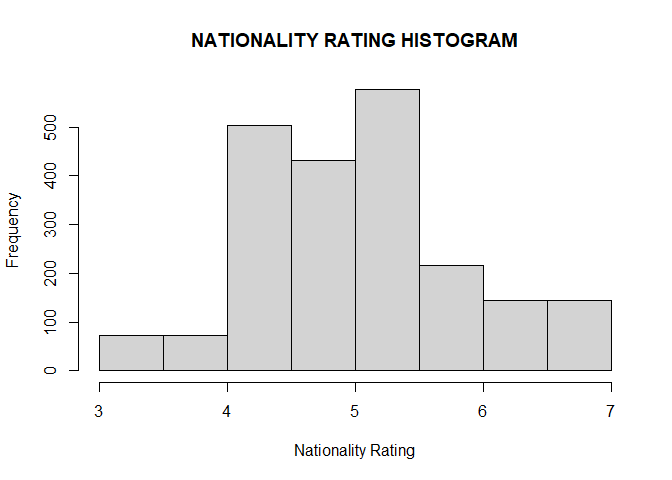

### Models

```
## Linear mixed model fit by REML. t-tests use Satterthwaite's method [
## lmerModLmerTest]
## Formula:
## SPEAKER_PERSONAL_RATING ~ ACCENT + NATION_TOTAL_RATING + PERSONAL_DIMENSION +
##     ACCENT:NATION_TOTAL_RATING + (1 | PART_ID) + (1 | PERC_SENT_ID)
##    Data: perc_data_var
##
## REML criterion at convergence: 4839.5
##
## Scaled residuals:
##     Min      1Q  Median      3Q     Max
## -4.4539 -0.5030  0.0495  0.6023  3.1823
##
## Random effects:
##  Groups       Name        Variance Std.Dev.
##  PERC_SENT_ID (Intercept) 0.0208   0.1442
##  PART_ID      (Intercept) 0.5411   0.7356
##  Residual                 0.4997   0.7069
## Number of obs: 2160, groups:  PERC_SENT_ID, 108; PART_ID, 30
##
## Fixed effects:
##                                     Estimate Std. Error         df t value
## (Intercept)                          3.14139    0.81085   28.68641   3.874
## ACCENTFOREIGN                       -0.04751    0.18447 2115.27663  -0.258
## NATION_TOTAL_RATING                  0.35665    0.15756   28.63327   2.264
## PERSONAL_DIMENSIONCOMP              -0.10949    0.03042 2023.10274  -3.599
## ACCENTFOREIGN:NATION_TOTAL_RATING    0.02201    0.03546 2078.09857   0.621
##                                   Pr(>|t|)
## (Intercept)                       0.000570 ***
## ACCENTFOREIGN                     0.796795
## NATION_TOTAL_RATING               0.031365 *
## PERSONAL_DIMENSIONCOMP            0.000327 ***
## ACCENTFOREIGN:NATION_TOTAL_RATING 0.534815
## ---
## Signif. codes:  0 '***' 0.001 '**' 0.01 '*' 0.05 '.' 0.1 ' ' 1
##
## Correlation of Fixed Effects:
##                (Intr) ACCENTFOREIGN NATION PERSON
## ACCENTFOREIGN  -0.114
## NATION_TOTA    -0.985  0.110
## PERSONAL_DI    -0.019  0.000         0.000
## ACCENTFOREIGN:  0.111 -0.975        -0.113  0.000
```

### Conclusion

*[I’m not sure how to analyse and interpret the interaction between a categorical (ACCENT) and continuous (NATION_TOTAL_RATING) variable. Turning Nationality Rating into a categorical variable could help because then we could check the contrasts (e.g. Nation:Low - Nation:High) for native and foreign accent separately. I tried to do this below. -PG]*

## 2B. HYPOTHESIS 10(B)

### Prediction

More positive attitude towards the foreign nationality (NATION_TOTAL_RATING_CAT) will correspond to more positive assessment of the personality traits (SPEAKER_PERSONAL_RATING) of the foreign-accented speakers (ACCENT).

*[This analysis is like the one above, except that it uses a categorical nationality rating instead of continuous. -PG]*

*[I again added Personality Dimension as a factor to the model. -PG]*

### Variables

**Personality Rating (SPEAKER_PERSONAL_RATING)**

See above.

**Categorical Nationality Rating (NATION_TOTAL_RATING_CAT)**

Outcome variable measured in the Online Questionnaire. Created by averaging the ratings for 8 adjectives describing the foreign nationality (German/Polish) in terms of warmth and competence and then by converting it into a categorical variable with two levels: LOW (less than or equal to the mean Nationality Rating of the group), HIGH (more than the mean Nationality Rating of the group). The conversion was done separately for Polish and German participants (using a different mean for each group).

**Personality Dimension (PERSONAL_DIMENSION)**

See above.

**Accent (ACCENT)**

See above.

### Descriptive statistics, plots

### Models

```
## Linear mixed model fit by REML. t-tests use Satterthwaite's method [
## lmerModLmerTest]
## Formula: SPEAKER_PERSONAL_RATING ~ ACCENT + NATION_TOTAL_RATING_CAT +
##     PERSONAL_DIMENSION + ACCENT:NATION_TOTAL_RATING_CAT + (1 |
##     PART_ID) + (1 | PERC_SENT_ID)
##    Data: perc_data_var
##
## REML criterion at convergence: 4840.5
##
## Scaled residuals:
##     Min      1Q  Median      3Q     Max
## -4.4627 -0.4997  0.0504  0.5993  3.1864
##
## Random effects:
##  Groups       Name        Variance Std.Dev.
##  PERC_SENT_ID (Intercept) 0.02078  0.1442
##  PART_ID      (Intercept) 0.60296  0.7765
##  Residual                 0.49973  0.7069
## Number of obs: 2160, groups:  PERC_SENT_ID, 108; PART_ID, 30
##
## Fixed effects:
##                                            Estimate Std. Error         df
## (Intercept)                                 5.15092    0.20432   29.42114
## ACCENTFOREIGN                               0.07765    0.05130  242.72497
## NATION_TOTAL_RATING_CATLOW                 -0.40207    0.28684   28.57159
## PERSONAL_DIMENSIONCOMP                     -0.10949    0.03042 2023.07436
## ACCENTFOREIGN:NATION_TOTAL_RATING_CATLOW   -0.02706    0.06121 2075.00608
##                                          t value Pr(>|t|)
## (Intercept)                               25.210  < 2e-16 ***
## ACCENTFOREIGN                              1.514 0.131432
## NATION_TOTAL_RATING_CATLOW                -1.402 0.171772
## PERSONAL_DIMENSIONCOMP                    -3.599 0.000327 ***
## ACCENTFOREIGN:NATION_TOTAL_RATING_CATLOW  -0.442 0.658506
## ---
## Signif. codes:  0 '***' 0.001 '**' 0.01 '*' 0.05 '.' 0.1 ' ' 1
##
## Correlation of Fixed Effects:
##                (Intr) ACCENTFOREIGN NATION PERSON
## ACCENTFOREIGN  -0.126
## NATION_TOTA    -0.702  0.064
## PERSONAL_DI    -0.074  0.000         0.000
## ACCENTFOREIGN:  0.075 -0.597        -0.107  0.000
```

```
## ACCENT = NATIVE:
##  NATION_TOTAL_RATING_CAT emmean    SE   df lower.CL upper.CL
##  HIGH                      5.10 0.204 29.1     4.68     5.51
##  LOW                       4.69 0.204 29.1     4.28     5.11
##
## ACCENT = FOREIGN:
##  NATION_TOTAL_RATING_CAT emmean    SE   df lower.CL upper.CL
##  HIGH                      5.17 0.204 29.1     4.76     5.59
##  LOW                       4.74 0.204 29.1     4.33     5.16
##
## Results are averaged over the levels of: PERSONAL_DIMENSION
## Degrees-of-freedom method: kenward-roger
## Confidence level used: 0.95
```

```
## ACCENT = NATIVE:
##  contrast   estimate    SE   df t.ratio p.value
##  HIGH - LOW    0.402 0.287 28.6   1.402  0.1718
##
## ACCENT = FOREIGN:
##  contrast   estimate    SE   df t.ratio p.value
##  HIGH - LOW    0.429 0.287 28.6   1.496  0.1456
##
## Results are averaged over the levels of: PERSONAL_DIMENSION
## Degrees-of-freedom method: kenward-roger
```

### Conclusion

The prediction was not confirmed. Participants who rated the foreign nationality higher than the average of the participant group gave somewhat more positive ratings of speaker personality traits, but the difference was not statistically significant either for native or for foreign accent.

## 3. HYPOTHESIS 11

### Prediction

Lower accent strength ratings (SPEAKER_ACCENT_STRENGTH_RATING) will correspond to more positive assessment of the speaker’s personality traits (SPEAKER_PERSONAL_RATING).

*[I again added Personality Dimension as a factor to the model. -PG]*

### Variables

**Accent Strength Rating (SPEAKER_ACCENT_STRENGTH_RATING)**

Outcome variable measured in Perceptual experiment. Ratings of the strength of the speaker’s accent (scale 1-7) given for each sentence.

**Personality Rating (SPEAKER_PERSONAL_RATING)**

See above.

**Personality Dimension (PERSONAL_DIMENSION)**

See above.

### Descriptive statistics, plots

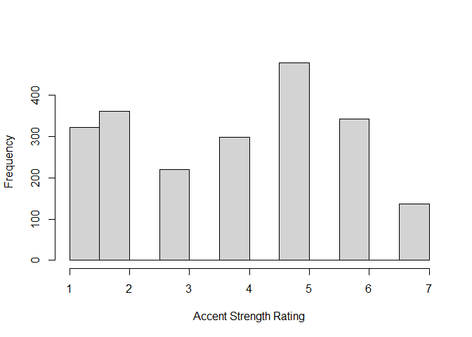

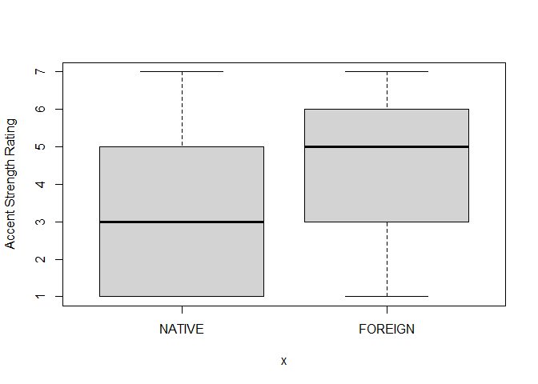

### Models

```
## Linear mixed model fit by REML. t-tests use Satterthwaite's method [
## lmerModLmerTest]
## Formula:
## SPEAKER_PERSONAL_RATING ~ SPEAKER_ACCENT_STRENGTH_RATING + PERSONAL_DIMENSION +
##     (1 | PART_ID) + (1 | PERC_SENT_ID)
##    Data: perc_data_var
##
## REML criterion at convergence: 4837.1
##
## Scaled residuals:
##     Min      1Q  Median      3Q     Max
## -4.3393 -0.4998  0.0508  0.5945  3.1783
##
## Random effects:
##  Groups       Name        Variance Std.Dev.
##  PERC_SENT_ID (Intercept) 0.02213  0.1487
##  PART_ID      (Intercept) 0.61617  0.7850
##  Residual                 0.49797  0.7057
## Number of obs: 2160, groups:  PERC_SENT_ID, 108; PART_ID, 30
##
## Fixed effects:
##                                  Estimate Std. Error         df t value
## (Intercept)                       5.08520    0.15123   34.99740   33.62
## SPEAKER_ACCENT_STRENGTH_RATING   -0.02694    0.01065  697.27209   -2.53
## PERSONAL_DIMENSIONCOMP           -0.10902    0.03037 2023.07798   -3.59
##                                Pr(>|t|)
## (Intercept)                     < 2e-16 ***
## SPEAKER_ACCENT_STRENGTH_RATING 0.011640 *
## PERSONAL_DIMENSIONCOMP         0.000339 ***
## ---
## Signif. codes:  0 '***' 0.001 '**' 0.01 '*' 0.05 '.' 0.1 ' ' 1
##
## Correlation of Fixed Effects:
##             (Intr) SPEAKE
## SPEAKER_ACC -0.270
## PERSONAL_DI -0.099 -0.006
```

### Conclusion

Prediction is confirmed. As the perceived accent strength of the speaker increases, the ratings of the personality traits get more negative.